# The Bigger Picture

Autumn 2025

## Let’s take a look at the rest of the Universe

## We had so much fun with quantum on Monday

> I thought I’d carry on pushing your minds, using mathematical concepts to understand and interpret the external world
- You may agree with some things, disagree with othes, and find some of this unsettling.

## Light Cones

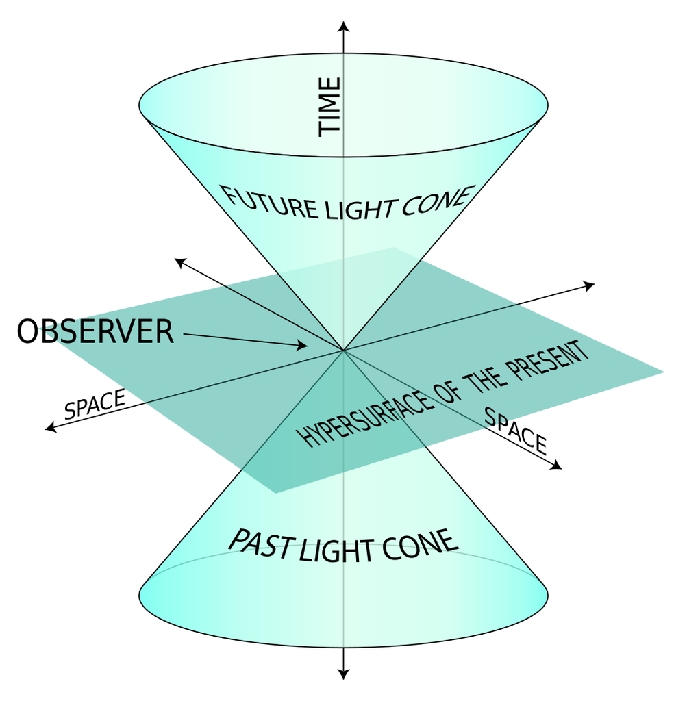

- Describes all the events in time and space as they interract with an observer at a central point.
- Light originating in the “past”, from an observer’s point of view, will travel to their position and then onwards.
- As light gets closer to the observer, the amount of past time the observer can “see” decreases, as light has less time to travel to the observer.

## Describing a series of events

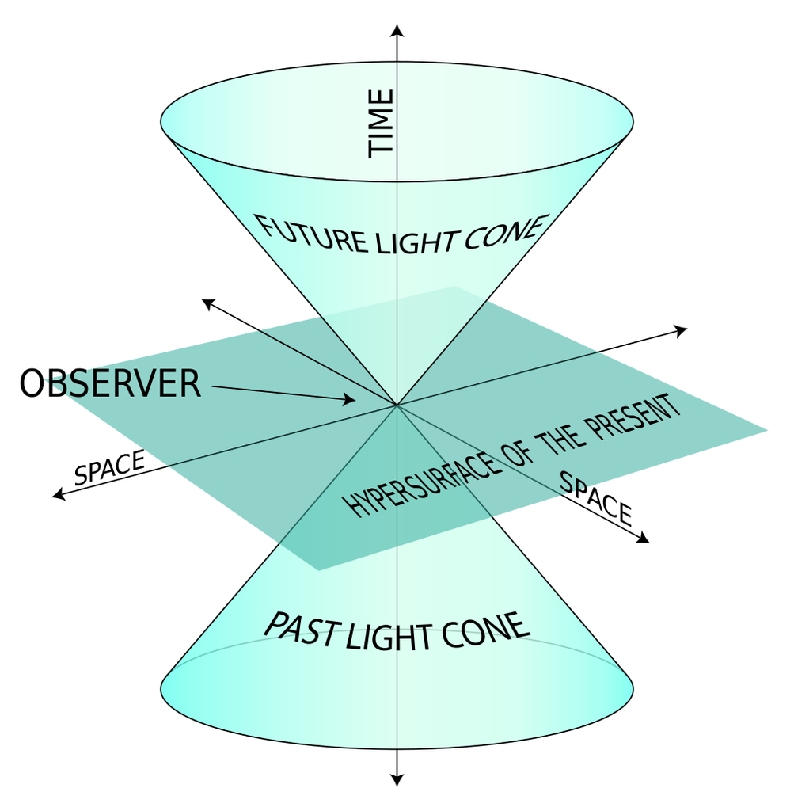

## Size of our galaxy

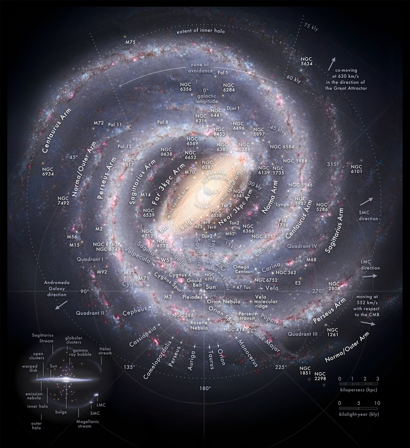

- Our galaxy is around **87,400 ± 3,590 light-years** according to our observations.
- Light we see from the other side of the galaxy, e.g., from stars, left **87,000 years ago**
  - Probably longer, since our galaxy is spinning.
  - 87,000 years ago, Neanderthals were the dominant human species on earth

## Dark Matter

Dark matter provides an answer to the following questions:

1. Why are galaxies moving so slowly through space?
2. Why are galaxies clumped together at certain locations?
3. Why are galaxies moving away from each other when gravity should be pulling them together?

## The plot thickens

- Current standard model of the universe is *Lambda-CDM*, this agrees with our current calculations.
- **5%** of the universe is composed of ordinary matter
- **26.8%** is composed of dark matter
- **68.2%** is composed of *dark energy*
- Dark energy, like dark matter, is a phenominon that we cannot see and cannot measure.
- Conclusion: **95%** of the universe is unobservable.

## Some numbers…

- The Milky Way consists of between 100 - 400 billion stars
- The centre of our galaxy contains a supermassive blackhole called Sagittarius A*
- It is 4 million times heavier than our sun
- Nearest galaxy to us (Andromeda) is **~2.5 million light-years** from earth

  (that’s without accounting for dark matter)
- Andromeda is expected to crash into our galaxy in around 4 - 5 billion years

  (dark matter pulling galaxies together)

## Small fry

- We are located in a cluster of three galaxies: Milky Way, Andromeda, Triangulum.
- Each of these galaxies have smaller satelite galaxies
- Our cluster is around 10 million light-years in diameter

[figure not shown]

## Even smaller fry

- Our cluster is part of the Virgo Supercluster.
- Virgo contains around 100 such galaxy groups (some larger, some smaller)
- Virgo has a diameter of around **110 million light-years**
- THere are **10 million** superclusters in the observable universe

## In summary

- The quantum world is “weird”, following different rules to classical physics.
- Our tiny corner of the known universe is miniascule compared to surrounding clusters.
- Classical matter (not dark matter / energy) comprises only \(5\%\) of the known universe.

[video not shown]

https://youtu.be/8Are9dDbW24